# IODS course project

```r
summary(Boston)
```

```
##       crim                zn             indus            chas
##  Min.   : 0.00632   Min.   :  0.00   Min.   : 0.46   Min.   :0.00000
##  1st Qu.: 0.08204   1st Qu.:  0.00   1st Qu.: 5.19   1st Qu.:0.00000
##  Median : 0.25651   Median :  0.00   Median : 9.69   Median :0.00000
##  Mean   : 3.61352   Mean   : 11.36   Mean   :11.14   Mean   :0.06917
##  3rd Qu.: 3.67708   3rd Qu.: 12.50   3rd Qu.:18.10   3rd Qu.:0.00000
##  Max.   :88.97620   Max.   :100.00   Max.   :27.74   Max.   :1.00000
##       nox               rm             age              dis
##  Min.   :0.3850   Min.   :3.561   Min.   :  2.90   Min.   : 1.130
##  1st Qu.:0.4490   1st Qu.:5.886   1st Qu.: 45.02   1st Qu.: 2.100
##  Median :0.5380   Median :6.208   Median : 77.50   Median : 3.207
##  Mean   :0.5547   Mean   :6.285   Mean   : 68.57   Mean   : 3.795
##  3rd Qu.:0.6240   3rd Qu.:6.623   3rd Qu.: 94.08   3rd Qu.: 5.188
##  Max.   :0.8710   Max.   :8.780   Max.   :100.00   Max.   :12.127
##       rad              tax           ptratio          black
##  Min.   : 1.000   Min.   :187.0   Min.   :12.60   Min.   :  0.32
##  1st Qu.: 4.000   1st Qu.:279.0   1st Qu.:17.40   1st Qu.:375.38
##  Median : 5.000   Median :330.0   Median :19.05   Median :391.44
##  Mean   : 9.549   Mean   :408.2   Mean   :18.46   Mean   :356.67
##  3rd Qu.:24.000   3rd Qu.:666.0   3rd Qu.:20.20   3rd Qu.:396.23
##  Max.   :24.000   Max.   :711.0   Max.   :22.00   Max.   :396.90
##      lstat            medv
##  Min.   : 1.73   Min.   : 5.00
##  1st Qu.: 6.95   1st Qu.:17.02
##  Median :11.36   Median :21.20
##  Mean   :12.65   Mean   :22.53
##  3rd Qu.:16.95   3rd Qu.:25.00
##  Max.   :37.97   Max.   :50.00
```

Below I have standardized the dataset. The mean of the variable is substracted from all the values, and the result is divided by the standard deviation of the variable. Also, I have used the code from DataCamp excercise to make a categorial crime variable from the scaled crime variable using the quantiles as break points. The new categorial variable “crime” will replace the numeric “crim” variable. I have also used the code from DataCamp to partition the observations into train-set (80 % of obs.) and test-set (the rest of the obs.) for use later parts of this excercise.

```r
boston_scaled <- scale(Boston)
boston_scaled <- as.data.frame(boston_scaled)
summary(boston_scaled)
```

```
##       crim                 zn               indus
##  Min.   :-0.419367   Min.   :-0.48724   Min.   :-1.5563
##  1st Qu.:-0.410563   1st Qu.:-0.48724   1st Qu.:-0.8668
##  Median :-0.390280   Median :-0.48724   Median :-0.2109
##  Mean   : 0.000000   Mean   : 0.00000   Mean   : 0.0000
##  3rd Qu.: 0.007389   3rd Qu.: 0.04872   3rd Qu.: 1.0150
##  Max.   : 9.924110   Max.   : 3.80047   Max.   : 2.4202
##       chas              nox                rm               age
##  Min.   :-0.2723   Min.   :-1.4644   Min.   :-3.8764   Min.   :-2.3331
##  1st Qu.:-0.2723   1st Qu.:-0.9121   1st Qu.:-0.5681   1st Qu.:-0.8366
##  Median :-0.2723   Median :-0.1441   Median :-0.1084   Median : 0.3171
##  Mean   : 0.0000   Mean   : 0.0000   Mean   : 0.0000   Mean   : 0.0000
##  3rd Qu.:-0.2723   3rd Qu.: 0.5981   3rd Qu.: 0.4823   3rd Qu.: 0.9059
##  Max.   : 3.6648   Max.   : 2.7296   Max.   : 3.5515   Max.   : 1.1164
##       dis               rad               tax             ptratio
##  Min.   :-1.2658   Min.   :-0.9819   Min.   :-1.3127   Min.   :-2.7047
##  1st Qu.:-0.8049   1st Qu.:-0.6373   1st Qu.:-0.7668   1st Qu.:-0.4876
##  Median :-0.2790   Median :-0.5225   Median :-0.4642   Median : 0.2746
##  Mean   : 0.0000   Mean   : 0.0000   Mean   : 0.0000   Mean   : 0.0000
##  3rd Qu.: 0.6617   3rd Qu.: 1.6596   3rd Qu.: 1.5294   3rd Qu.: 0.8058
##  Max.   : 3.9566   Max.   : 1.6596   Max.   : 1.7964   Max.   : 1.6372
##      black             lstat              medv
##  Min.   :-3.9033   Min.   :-1.5296   Min.   :-1.9063
##  1st Qu.: 0.2049   1st Qu.:-0.7986   1st Qu.:-0.5989
##  Median : 0.3808   Median :-0.1811   Median :-0.1449
##  Mean   : 0.0000   Mean   : 0.0000   Mean   : 0.0000
##  3rd Qu.: 0.4332   3rd Qu.: 0.6024   3rd Qu.: 0.2683
##  Max.   : 0.4406   Max.   : 3.5453   Max.   : 2.9865
```

```r
# save the scaled crim as scaled_crim
scaled_crim <- scale(boston_scaled$crim)

# create a quantile vector of crim
bins <- quantile(scaled_crim)

# create a categorical variable 'crime'
crime <- cut(scaled_crim, breaks = bins, include.lowest = TRUE, label=c("low","med_low","med_hig","high") )

# remove original crim from the dataset
boston_scaled <- dplyr::select(boston_scaled, -crim)

# add the new categorical value to scaled data
boston_scaled <- data.frame(boston_scaled, crime)

# number of rows in the Boston dataset
n <- nrow(Boston)

# choose randomly 80% of the rows
ind <- sample(n,  size = n * 0.8)

# create train set
train <- boston_scaled[ind,]

# create test set
test <- boston_scaled[-ind,]
```

Next, we will fit linear discriminant analysis on the train-set and plot the results (with arrow plot from http://stackoverflow.com/questions/17232251/how-can-i-plot-a-biplot-for-lda-in-r)

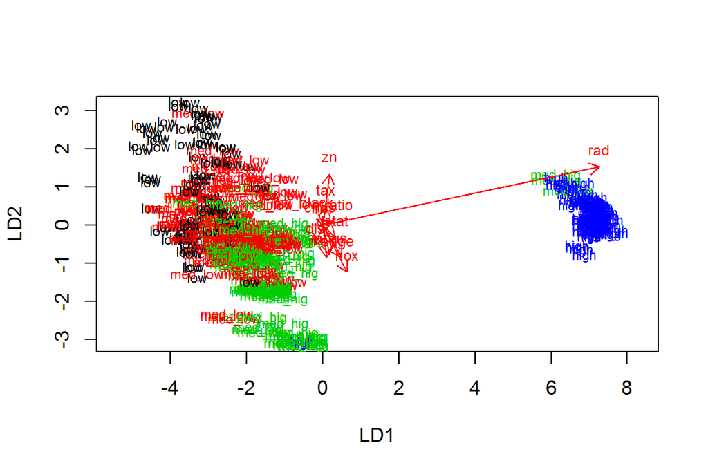

```r
# LDA fit on train-set
lda.fit <- lda(crime ~ . , data = train)

# arrow-function for the plotting
lda.arrows <- function(x, myscale = 1, arrow_heads = 0.1, color = "red", tex = 0.75, choices = c(1,2)){
  heads <- coef(x)
  arrows(x0 = 0, y0 = 0,
         x1 = myscale * heads[,choices[1]],
         y1 = myscale * heads[,choices[2]], col=color, length = arrow_heads)
  text(myscale * heads[,choices], labels = row.names(heads),
       cex = tex, col=color, pos=3)
}

# target classes as numeric (for arrow plot)
classes <- as.numeric(train$crime)

# plot the lda results
plot(lda.fit, dimen = 2, col=classes, pch = classes)
lda.arrows(lda.fit, myscale = 2)
```

```r
# save the correct classes from test data
correct_classes <- test$crime

# remove the crime variable from test data
test <- dplyr::select(test, -crime)

# predict classes with test data
lda.pred <- predict(lda.fit, newdata = test)

# cross tabulate the results
table(correct = correct_classes, predicted = lda.pred$class) %>% addmargins()
```

```
##          predicted
## correct   low med_low med_hig high Sum
##   low      13      11       4    0  28
##   med_low   5      12       4    0  21
##   med_hig   0       9      11    3  23
##   high      0       0       0   30  30
##   Sum      18      32      19   33 102
```

```r
data("Boston")
Boston <- scale(Boston)
dist_eu <- dist(Boston)
km <-kmeans(Boston, dist_eu, centers = 2)
```

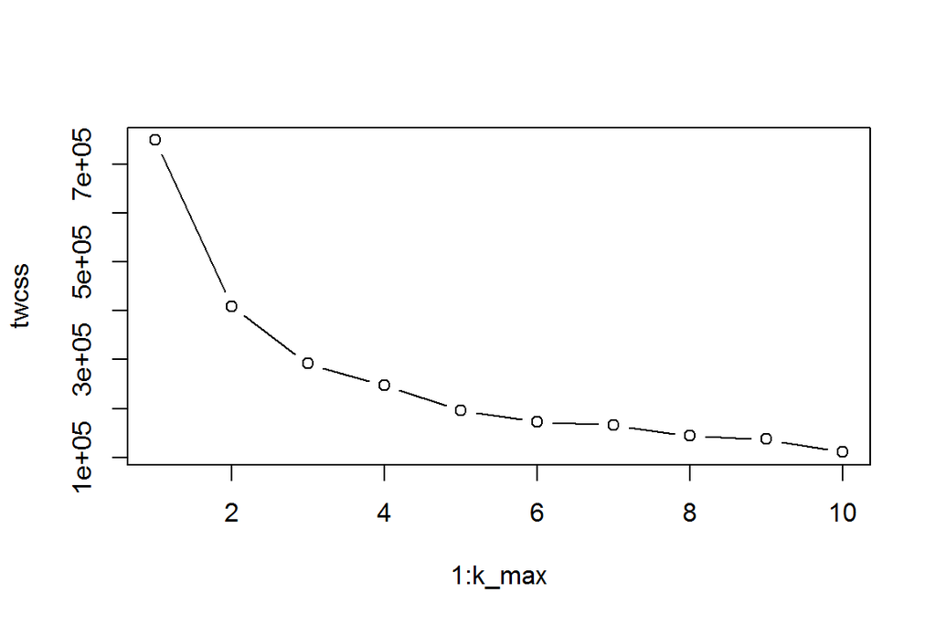

```r
# determine the number of clusters
k_max <- 10

# calculate the total within sum of squares
twcss <- sapply(1:k_max, function(k){kmeans(dist_eu, k)$tot.withinss})

# visualize the results
plot(1:k_max, twcss, type='b')
```

```r
km <-kmeans(Boston, dist_eu, centers = 3)
```

[figure not shown]

```r
# plot the Boston dataset with clusters
pairs(Boston, col = km$cluster)
```

Let us proceed to the bonus excercise. The idea is to cluster the scaled Boston data, and find the discriminating factors for the cluster using LDA. Acces to radial highways, nitric oxide concentration, and industrial environment are indicators of “bad neighbourhoods”, and together with full value property tax rate (per 10 000 $) discriminate one of the clusters. Room number, median price of owner occupied houses and proportion of residential land show “good neighbourhoods” and make another cluster. Age is the only variable that discroiminates especially towarsds the last (remaining) cluster. Could it be that some age group (old/young) tends to live yet in a very different environment? Maybe older couples tend to move once their offspring leave the house?

```r
# initialtion: load, scale, compute distances and run km-clustring (2-clusters)
data("Boston")
Boston <- scale(Boston)
Boston <- as.data.frame(Boston)
dist_eu <- dist(Boston)
km <-kmeans(Boston, dist_eu, centers = 3)
```

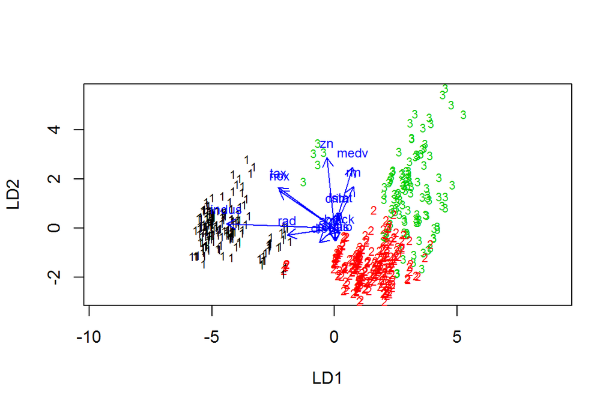

```r
# LDA
lda.fit <- lda(km$cluster ~ . , data = Boston)

# arrow-function for the plotting
lda.arrows <- function(x, myscale = 1, arrow_heads = 0.1, color = "blue", tex = 0.75, choices = c(1,2)){
  heads <- coef(x)
  arrows(x0 = 0, y0 = 0,
         x1 = myscale * heads[,choices[1]],
         y1 = myscale * heads[,choices[2]], col=color, length = arrow_heads)
  text(myscale * heads[,choices], labels = row.names(heads),
       cex = tex, col=color, pos=3)
}

# target classes as numeric (for arrow plot)
classes <- as.numeric(km$cluster)

# plot the lda results
plot(lda.fit, dimen = 2, col=classes, pch = classes)
lda.arrows(lda.fit, myscale = 3)
```

# Dimensionality reduction techniques

The data originates from a open access [webpage](http://hdr.undp.org/en/content/human-development-index-hdi). The human developmental index (HDI) was created to access the developmental stage of countries using human reserves (skills etc.) rather than industrial output of the country as the measure of the developmental stage. There are also variants of this index available. Overview of the calculations for obtaining the indices may be found [here](http://hdr.undp.org/sites/default/files/hdr2015_technical_notes.pdf).

Briefly, the aspects covered by HDI are

- long and healthy life (life expectancy)
- knowledge (through measured and expected years of education)
- standard of living (GNI per capita)

Gender equality index utilizes

- Maternar mortality ratio
- Adolescent birth rate
- Secondary education % in males and females separately
- % of females and males in labour market
- Proportion (%) of parliaments seats taken by females

Last week, we made modifications to the data. A meta file for the modified data is available [here](https://raw.githubusercontent.com/TuomoNieminen/Helsinki-Open-Data-Science/master/datasets/human_meta.txt). This week, we will utilize 8 variables from the modified data, i.e. ratio of proportions of population (the ratio of female % to male %) having secondary education (“Edu2.FM”“) and rate of participation in labour force (”Labo.FM“), expected years of schooling (”Edu.Exp“) and life (”Life.Exp“), gross national income (”GNI“”), maternal mortality rate (“Mat.Mor”), adolescent birth rate (“Ado.Birth”) and percent of parliament seats taken by females (“Parli.F”). Below the structure and the dimensions of the data are explored. The data now has 155 observations with data on all the 8 variables (observations with missing values were dropped out).

```r
str(human)
```

```
## 'data.frame':    155 obs. of  8 variables:
##  $ Edu2.FM  : num  1.007 0.997 0.983 0.989 0.969 ...
##  $ Labo.FM  : num  0.891 0.819 0.825 0.884 0.829 ...
##  $ Edu.Exp  : num  17.5 20.2 15.8 18.7 17.9 16.5 18.6 16.5 15.9 19.2 ...
##  $ Life.Exp : num  81.6 82.4 83 80.2 81.6 80.9 80.9 79.1 82 81.8 ...
##  $ GNI      : int  64992 42261 56431 44025 45435 43919 39568 52947 42155 32689 ...
##  $ Mat.Mor  : int  4 6 6 5 6 7 9 28 11 8 ...
##  $ Ado.Birth: num  7.8 12.1 1.9 5.1 6.2 3.8 8.2 31 14.5 25.3 ...
##  $ Parli.F  : num  39.6 30.5 28.5 38 36.9 36.9 19.9 19.4 28.2 31.4 ...
```

```r
dim(human)
```

```
## [1] 155   8
```

Let us next check the distributions of variables and correlations in the data. We see from the histograms below, that many of the variables have roughly bell shaped disributions. The bell shape is not at all evident in GNI, maternal mortality and adolescent birth rate (the bell shapes in these varibales are visibly “cut” from the left side as they start to reach zero as the minimal value). The rough bell shape of life expectancy histogram is cut from the side of the maximal value (close to 85 years). All the variables correlate quite strongly with each other (positively or negatively) except “Parli.F” and “Labo.FM”.

```r
summary (human)
```

```
##     Edu2.FM          Labo.FM          Edu.Exp         Life.Exp
##  Min.   :0.1717   Min.   :0.1857   Min.   : 5.40   Min.   :49.00
##  1st Qu.:0.7264   1st Qu.:0.5984   1st Qu.:11.25   1st Qu.:66.30
##  Median :0.9375   Median :0.7535   Median :13.50   Median :74.20
##  Mean   :0.8529   Mean   :0.7074   Mean   :13.18   Mean   :71.65
##  3rd Qu.:0.9968   3rd Qu.:0.8535   3rd Qu.:15.20   3rd Qu.:77.25
##  Max.   :1.4967   Max.   :1.0380   Max.   :20.20   Max.   :83.50
##       GNI            Mat.Mor         Ado.Birth         Parli.F
##  Min.   :   581   Min.   :   1.0   Min.   :  0.60   Min.   : 0.00
##  1st Qu.:  4198   1st Qu.:  11.5   1st Qu.: 12.65   1st Qu.:12.40
##  Median : 12040   Median :  49.0   Median : 33.60   Median :19.30
##  Mean   : 17628   Mean   : 149.1   Mean   : 47.16   Mean   :20.91
##  3rd Qu.: 24512   3rd Qu.: 190.0   3rd Qu.: 71.95   3rd Qu.:27.95
##  Max.   :123124   Max.   :1100.0   Max.   :204.80   Max.   :57.50
```

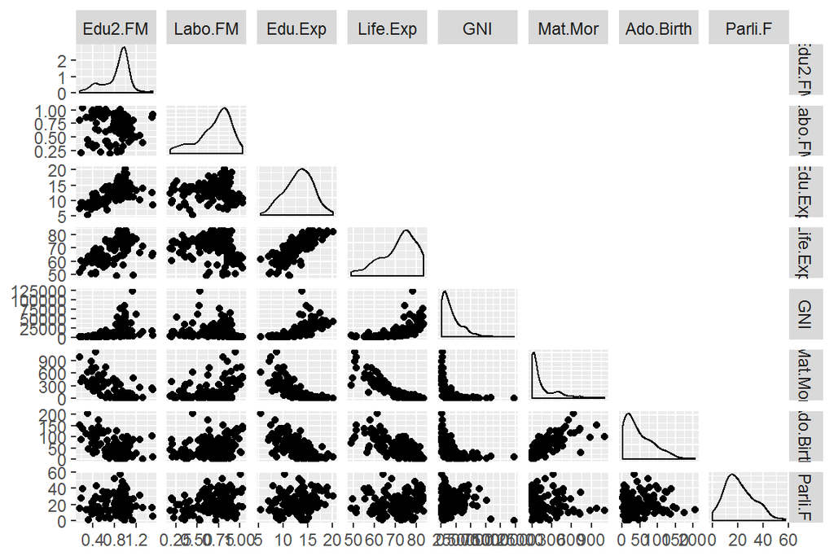

```r
p <- ggpairs(human, upper=NULL, lower = list(combo = wrap("facethist", bins = 20)))
p
```

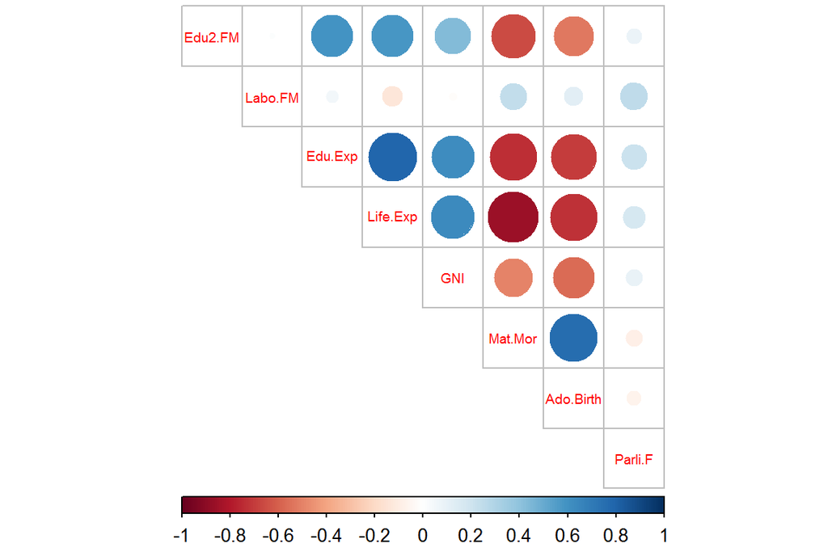

```r
# calculate the correlation matrix and round it
cor_matrix <- cor(human)  %>% round(digits=2)

# visualize the correlation matrix
corrplot(cor_matrix, method="circle", type ="upper", cl.pos="b", tl.pos="d", tl.cex=0.6)
```

```r
# print the correlation matrix
cor_matrix
```

```
##           Edu2.FM Labo.FM Edu.Exp Life.Exp   GNI Mat.Mor Ado.Birth Parli.F
## Edu2.FM      1.00    0.01    0.59     0.58  0.43   -0.66     -0.53    0.08
## Labo.FM      0.01    1.00    0.05    -0.14 -0.02    0.24      0.12    0.25
## Edu.Exp      0.59    0.05    1.00     0.79  0.62   -0.74     -0.70    0.21
## Life.Exp     0.58   -0.14    0.79     1.00  0.63   -0.86     -0.73    0.17
## GNI          0.43   -0.02    0.62     0.63  1.00   -0.50     -0.56    0.09
## Mat.Mor     -0.66    0.24   -0.74    -0.86 -0.50    1.00      0.76   -0.09
## Ado.Birth   -0.53    0.12   -0.70    -0.73 -0.56    0.76      1.00   -0.07
## Parli.F      0.08    0.25    0.21     0.17  0.09   -0.09     -0.07    1.00
```

Let us try principal component analysis without standardizing the data first, and let us visualise the results using a biplot. Then let us perform the same operation on standardized data. The results show how the variable with largest variance in the unstandardized data (GNI) will be weighed over all the other variables of the unstandardized data. The standardized data show much more proader distribution of the observations on the scatter plot with two prinsipal components describing the highest amount of variance. There, “Labor.FM” and “Parli.F” seem somewhat correlated with principal component no:2 and all the other components show positive and negative correlation with principal component no:1. This was to be expected from the correlations we saw earlier while inspecting the data. Here the arrow sizes are the same (due to standardization of the data). I take the result to mean, that educating all kids will also lead to females going towards secondary education and not having babies as young, and increase the life expectancy maybe at least partly due to reduced maternal mortality.

```r
# PCA
pca_human <- prcomp(human)

# variability by the principal components
s <- summary(pca_human)
pca_pr <- round(1*s$importance[2, ]*100, digits = 1)
pca_pr
```

```
## PC1 PC2 PC3 PC4 PC5 PC6 PC7 PC8
## 100   0   0   0   0   0   0   0
```

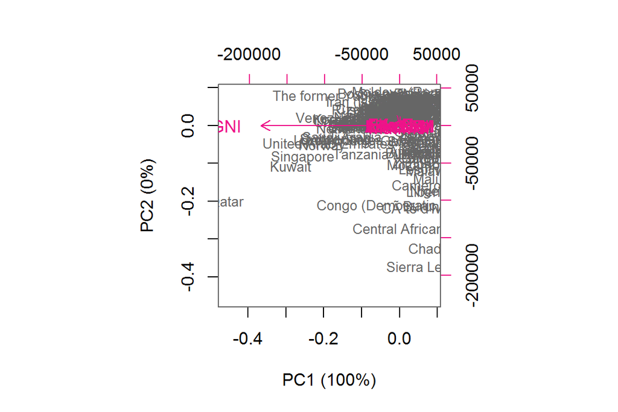

```r
# biplot
pc_lab <- paste0(names(pca_pr), " (", pca_pr, "%)")
biplot(pca_human, cex = c(0.8, 1), col = c("grey40", "deeppink2"), xlab = pc_lab[1], ylab = pc_lab[2])
```

```r
# PCA on scaled human
human_scaled <- scale(human)
pca_human_scaled <- prcomp(human_scaled)

# variability by the principal components
s <- summary(pca_human_scaled)
pca_pr_scaled <- round(1*s$importance[2, ]*100, digits = 1)
pca_pr_scaled
```

```
##  PC1  PC2  PC3  PC4  PC5  PC6  PC7  PC8
## 53.6 16.2  9.6  7.6  5.5  3.6  2.6  1.3
```

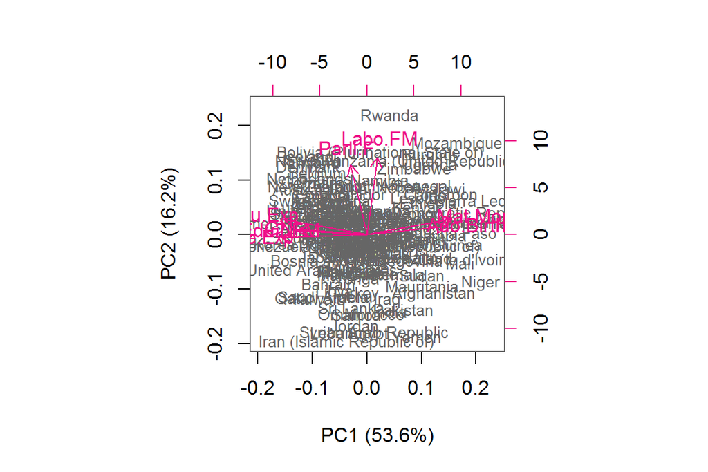

```r
# biplot
pc_lab_scaled <- paste0(names(pca_pr_scaled), " (", pca_pr_scaled, "%)")
biplot(pca_human_scaled, cex = c(0.8, 1), col = c("grey40", "deeppink2"), xlab = pc_lab_scaled[1], ylab = pc_lab_scaled[2])
```

Next: tea data exploration, multiple correspondency analysis on tea data, and graphical presentation of the results.

```r
library(FactoMineR)
data(tea)

# keep only part of data
keep_columns <- c("Tea", "How", "how", "sugar", "where", "lunch")
tea <- dplyr::select(tea, one_of(keep_columns))

#Explore and vizualise the variables:
str(tea)
```

```
## 'data.frame':    300 obs. of  6 variables:
##  $ Tea  : Factor w/ 3 levels "black","Earl Grey",..: 1 1 2 2 2 2 2 1 2 1 ...
##  $ How  : Factor w/ 4 levels "alone","lemon",..: 1 3 1 1 1 1 1 3 3 1 ...
##  $ how  : Factor w/ 3 levels "tea bag","tea bag+unpackaged",..: 1 1 1 1 1 1 1 1 2 2 ...
##  $ sugar: Factor w/ 2 levels "No.sugar","sugar": 2 1 1 2 1 1 1 1 1 1 ...
##  $ where: Factor w/ 3 levels "chain store",..: 1 1 1 1 1 1 1 1 2 2 ...
##  $ lunch: Factor w/ 2 levels "lunch","Not.lunch": 2 2 2 2 2 2 2 2 2 2 ...
```

```r
dim(tea)
```

```
## [1] 300   6
```

```r
summary (tea)
```

```
##         Tea         How                      how           sugar
##  black    : 74   alone:195   tea bag           :170   No.sugar:155
##  Earl Grey:193   lemon: 33   tea bag+unpackaged: 94   sugar   :145
##  green    : 33   milk : 63   unpackaged        : 36
##                  other:  9
##                   where           lunch
##  chain store         :192   lunch    : 44
##  chain store+tea shop: 78   Not.lunch:256
##  tea shop            : 30
##
```

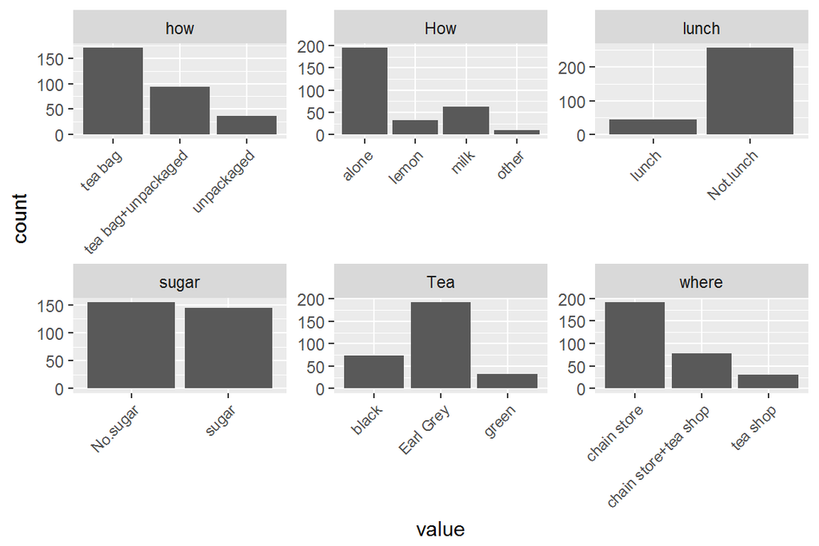

```r
gather(tea) %>% ggplot(aes(value)) + facet_wrap("key", scales = "free") + geom_bar() + theme(axis.text.x = element_text(angle = 45, hjust = 1, size = 8))
```

```r
# multiple correspondence analysis
mca <- MCA(tea, graph = FALSE)

# summary of the model
summary(mca)
```

```
##
## Call:
## MCA(X = tea, graph = FALSE)
##
##
## Eigenvalues
##                        Dim.1   Dim.2   Dim.3   Dim.4   Dim.5   Dim.6
## Variance               0.279   0.261   0.219   0.189   0.177   0.156
## % of var.             15.238  14.232  11.964  10.333   9.667   8.519
## Cumulative % of var.  15.238  29.471  41.435  51.768  61.434  69.953
##                        Dim.7   Dim.8   Dim.9  Dim.10  Dim.11
## Variance               0.144   0.141   0.117   0.087   0.062
## % of var.              7.841   7.705   6.392   4.724   3.385
## Cumulative % of var.  77.794  85.500  91.891  96.615 100.000
##
## Individuals (the 10 first)
##                       Dim.1    ctr   cos2    Dim.2    ctr   cos2    Dim.3
## 1                  | -0.298  0.106  0.086 | -0.328  0.137  0.105 | -0.327
## 2                  | -0.237  0.067  0.036 | -0.136  0.024  0.012 | -0.695
## 3                  | -0.369  0.162  0.231 | -0.300  0.115  0.153 | -0.202
## 4                  | -0.530  0.335  0.460 | -0.318  0.129  0.166 |  0.211
## 5                  | -0.369  0.162  0.231 | -0.300  0.115  0.153 | -0.202
## 6                  | -0.369  0.162  0.231 | -0.300  0.115  0.153 | -0.202
## 7                  | -0.369  0.162  0.231 | -0.300  0.115  0.153 | -0.202
## 8                  | -0.237  0.067  0.036 | -0.136  0.024  0.012 | -0.695
## 9                  |  0.143  0.024  0.012 |  0.871  0.969  0.435 | -0.067
## 10                 |  0.476  0.271  0.140 |  0.687  0.604  0.291 | -0.650
##                       ctr   cos2
## 1                   0.163  0.104 |
## 2                   0.735  0.314 |
## 3                   0.062  0.069 |
## 4                   0.068  0.073 |
## 5                   0.062  0.069 |
## 6                   0.062  0.069 |
## 7                   0.062  0.069 |
## 8                   0.735  0.314 |
## 9                   0.007  0.003 |
## 10                  0.643  0.261 |
##
## Categories (the 10 first)
```

[output cut: 16 more lines]

```
## lemon                0.035   3.226 |   1.329  14.771   0.218   8.081 |
## milk                 0.020   2.422 |   0.013   0.003   0.000   0.116 |
## other                0.102   5.534 |  -2.524  14.526   0.197  -7.676 |
## tea bag              0.161  -6.941 |  -0.065   0.183   0.006  -1.287 |
## tea bag+unpackaged   0.478  11.956 |   0.019   0.009   0.000   0.226 |
## unpackaged           0.141  -6.482 |   0.257   0.602   0.009   1.640 |
##
## Categorical variables (eta2)
##                      Dim.1 Dim.2 Dim.3
## Tea                | 0.126 0.108 0.410 |
## How                | 0.076 0.190 0.394 |
## how                | 0.708 0.522 0.010 |
## sugar              | 0.065 0.001 0.336 |
## where              | 0.702 0.681 0.055 |
## lunch              | 0.000 0.064 0.111 |
```

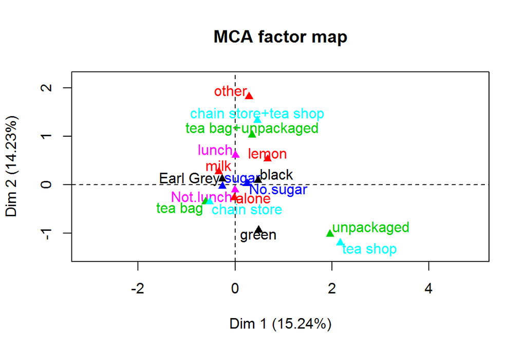

```r
# visualize MCA
plot(mca, invisible=c("ind"), habillage = "quali")
```